# Statistics Teaching

# F-tests

F tests are most commonly used for two purposes:

1. in ANOVA, for testing equality of means (and various similar analyses); and
2. in testing equality of variances

```
##        value        numdf        dendf
## 1.592065e-30 2.000000e+00 2.700000e+01
```

```
##     value     numdf     dendf
##  3.272727  2.000000 27.000000
```

```
##     value     numdf     dendf
##  9.818182  2.000000 27.000000
```

```
##    value    numdf    dendf
## 101.4545   2.0000  27.0000
```

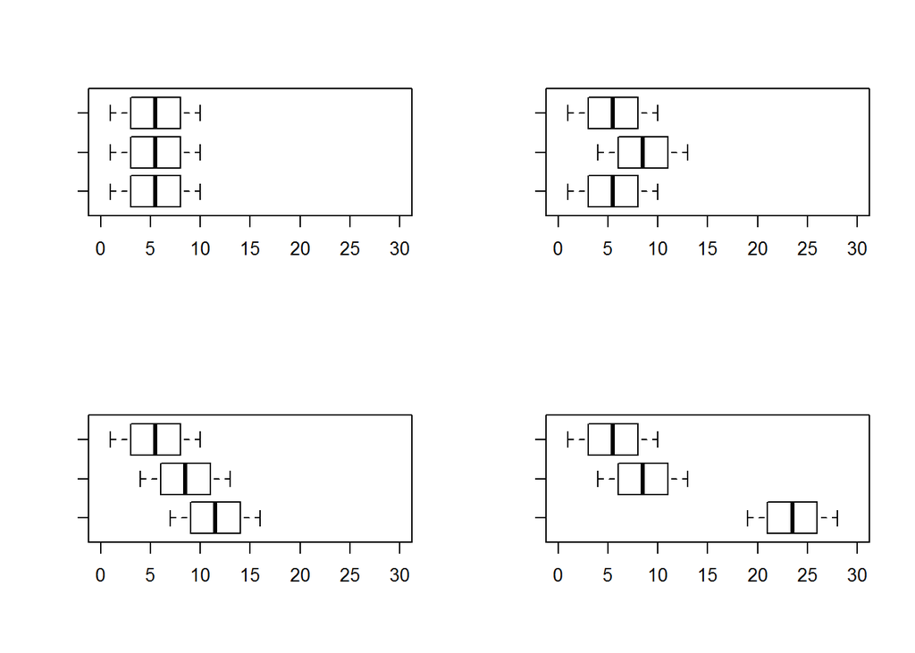

If the null hypothesis (equality of population means) were true, you’d expect some variation in sample means, and would typically expect to see F ratios roughly around 1. Smaller F statistics result from samples that are closer together than you’d typically expect, so you aren’t going to conclude the population means differ.

That is, for ANOVA, you’ll reject the hypothesis of equality of means when you get unusually large F-values and you won’t reject the hypothesis of equality of means when you get unusually small values (it may indicate something, but not that the population means differ).

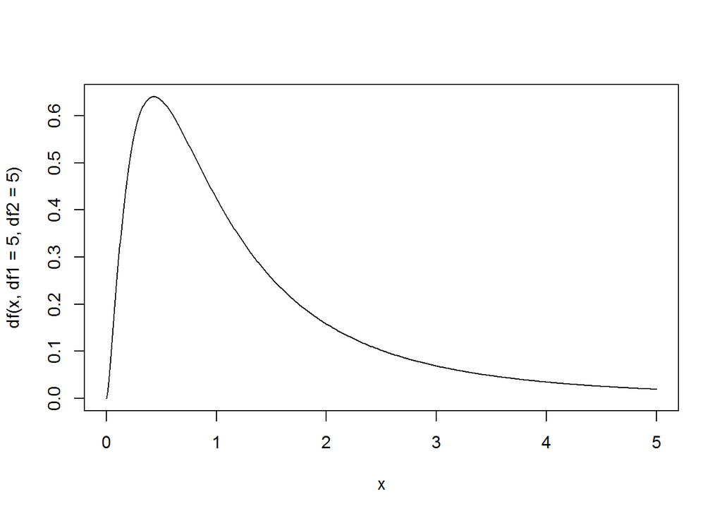

```r
x<-seq(0,5,0.01); plot(x,df(x,df1=5,df2=5), type="l")
```

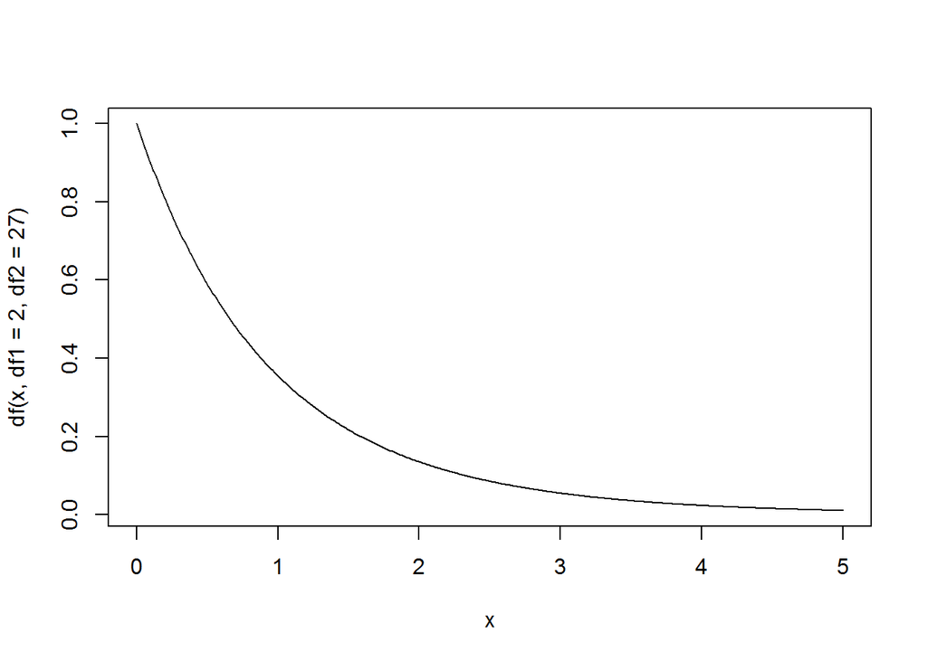

```r
x<-seq(0,5,0.01); plot(x,df(x,df1=2,df2=27), type="l")
```

This illustration shows that we only want to reject when F is in its upper tail.

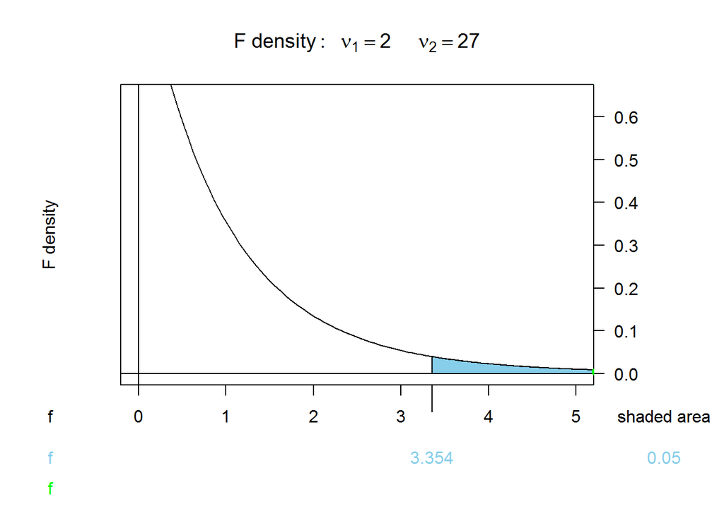

# Probability Density Functions

The “bell curve” shape is governed by the PDF. However, the actual “y”-value of this curve is itself more or less meaningless. The integral of the PDF $f(x)$ gives the probability that your random variable is less than some value:

$P(x<X) = \int_{\infty}^{X}f(x)dx$.

This is known as the CDF, or cumulative distribution function. By the fundamental theorem of calculus, the PDF is then the derivative of the CDF; that is, the PDF is the derivative of a function that returns a probability. So what is that intuitively? Honestly… it’s not really anything. The “units” of the vertical axis in the PDF plot don’t lead to anything intuitive; they are meaningful, but only in a derived, mathematical sense.

The area under the pdf equals 1. If the pdf value $f(x)$ exceeds 1 for some and indeed many values of $x$, that is perfectly fine: but $f(x)$ cannot exceed 1 for all $x$ in an interval $I$ of length exceeding 1. If the latter condition were to hold, then:

$\int_{I}^{}f(x)dx$ = area under pdf in interval I > 1

in violation of the constraint that the total area is 1. The value of $f(x)$ is not a probability. The units of $f(x)$ are probability per unit length and you must multiply by length (more generally, find an area) to get a probability.

As a consequence, some people wish to think that $f(X)$ is the probability that $x=X$, but this is untrue for continuous distributions $(P(x=X)=0)$. However, for the PDF’s discrete analog, the Probability Mass Function (PMF), this statement is quite true.

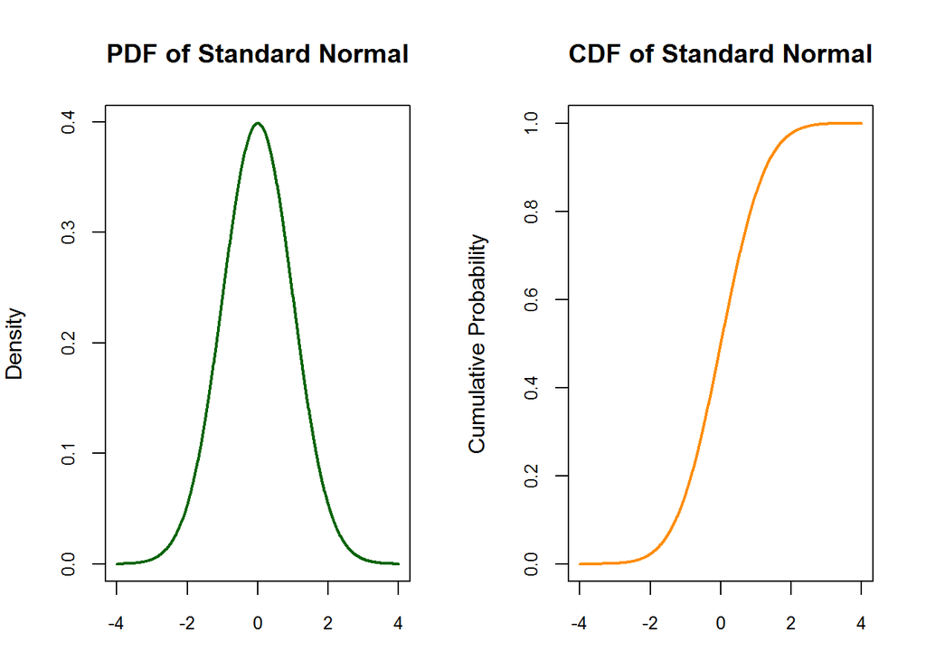

## Interactions

Interactions allow us assess the extent to which the association between one predictor and the outcome depends on a second predictor.